# Shut Up & Sit Down Podscast Analysis

## Are the variables correlated?

There are a significant number of correlated variables in the dataset. Sadly, it seems that there are not many correlations between databases.

Of note is an interesting pattern - positive sentimend in negatively correlated with the neutral sentiment, but a similar correlation between negative and neutral is much weaker.

Positive and negative sentiment also has only a weak negative correlation.

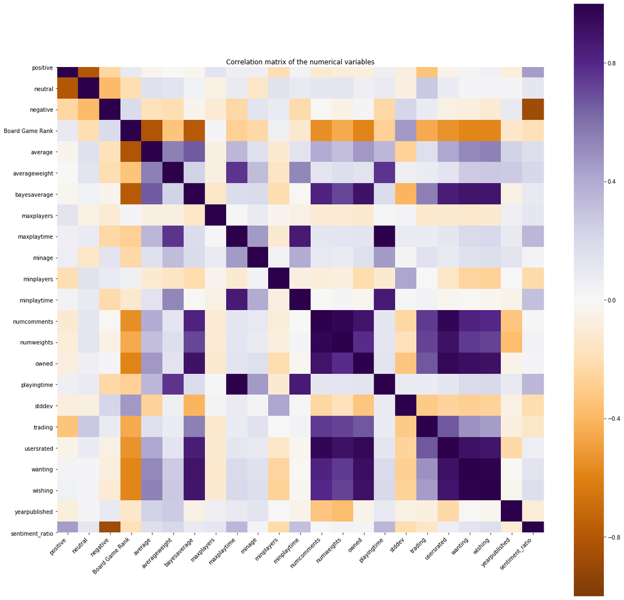

```python
fig, ax = plt.subplots(figsize=(20,20))
corr = grouped_results[['positive',
                        'neutral',
                        'negative',
                        'Board Game Rank',
                        'average',
                        'averageweight',
                        'bayesaverage',
                        'maxplayers',
                        'maxplaytime',
                        'minage',
                        'minplayers',
                        'minplaytime',
                        'numcomments',
                        'numweights',
                        'owned',
                        'playingtime',
                        'stddev',
                        'trading',
                        'usersrated',
                        'wanting',
                        'wishing',
                        'yearpublished',
                        'sentiment_ratio']].corr()
ax = sns.heatmap(
    corr,
    vmin=-1, vmax=1, center=0,
    cmap="PuOr",
    square=True
)
ax.set_xticklabels(
    ax.get_xticklabels(),
    rotation=45,
    horizontalalignment='right'
);
plt.title('Correlation matrix of the numerical variables')
plt.show()
```

If we run the analisys on the paragraphs and not on the text, all correlations between datasets dissapear.

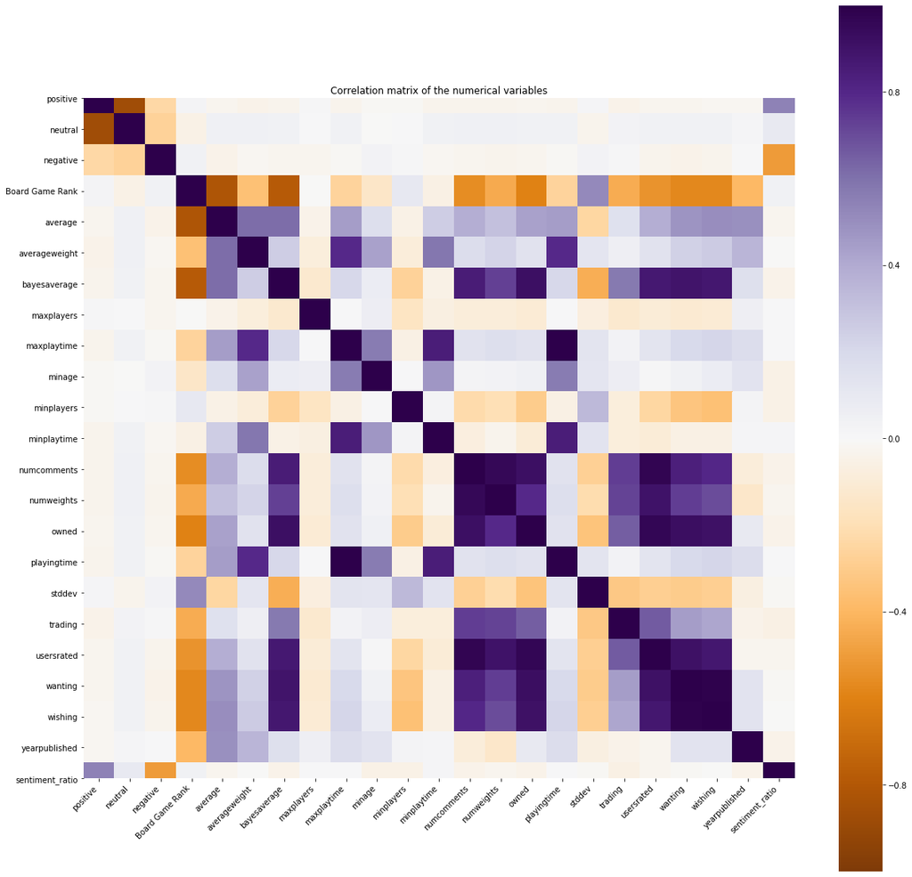

```python
fig, ax = plt.subplots(figsize=(20,20))
corr = results[['positive',
                        'neutral',
                        'negative',
                        'Board Game Rank',
                        'average',
                        'averageweight',
                        'bayesaverage',
                        'maxplayers',
                        'maxplaytime',
                        'minage',
                        'minplayers',
                        'minplaytime',
                        'numcomments',
                        'numweights',
                        'owned',
                        'playingtime',
                        'stddev',
                        'trading',
                        'usersrated',
                        'wanting',
                        'wishing',
                        'yearpublished',
                        'sentiment_ratio']].corr()
ax = sns.heatmap(
    corr,
    vmin=-1, vmax=1, center=0,
    cmap="PuOr",
    square=True
)
ax.set_xticklabels(
    ax.get_xticklabels(),
    rotation=45,
    horizontalalignment='right'
);
plt.title('Correlation matrix of the numerical variables')
plt.show()
```

## What are the patterns of sentiment in the reviews?

It looks like the sentiment for all reviews hover around means. There are no significant outliers, all games follow the patternm.

For neutral the mean would be ~ 65%, for positive ~ 25% and for negative ~ 10%. This means that for the most part, the reviewers focus on the games. When they voice their opinions it is more than 2x likely that they the opinion will be positive.

This is an important information, because this may indicate that most games choosen for the podcast are good, or at least, are liked by the participants.

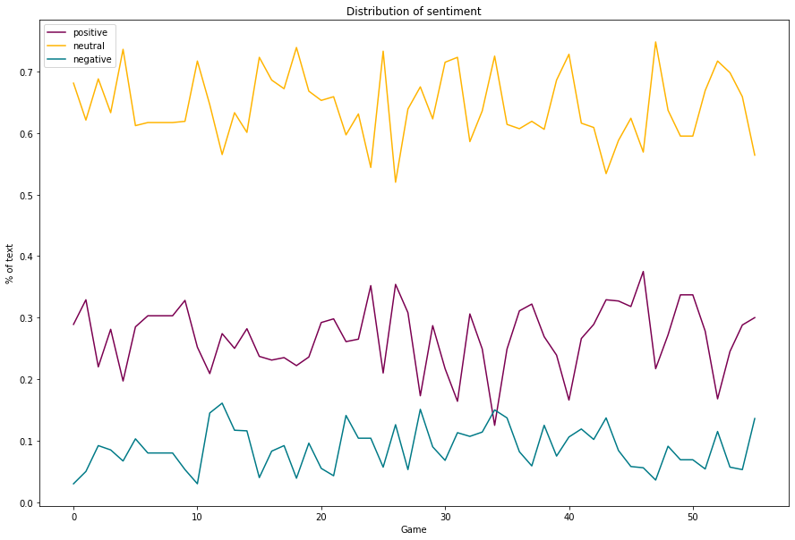

```python
fig, ax = plt.subplots(figsize=(15,10))
ax.plot('positive', data = grouped_results, color = purple)
ax.plot('neutral', data = grouped_results, color = orange)
ax.plot('negative', data = grouped_results, color = blueGreen)
handles, labels = ax.get_legend_handles_labels()
ax.legend(handles, labels)
plt.title('Distribution of sentiment')
plt.ylabel('% of text')
plt.xlabel('Game')
plt.show()
```

The same plot as above, but in a way that is probably more clear.

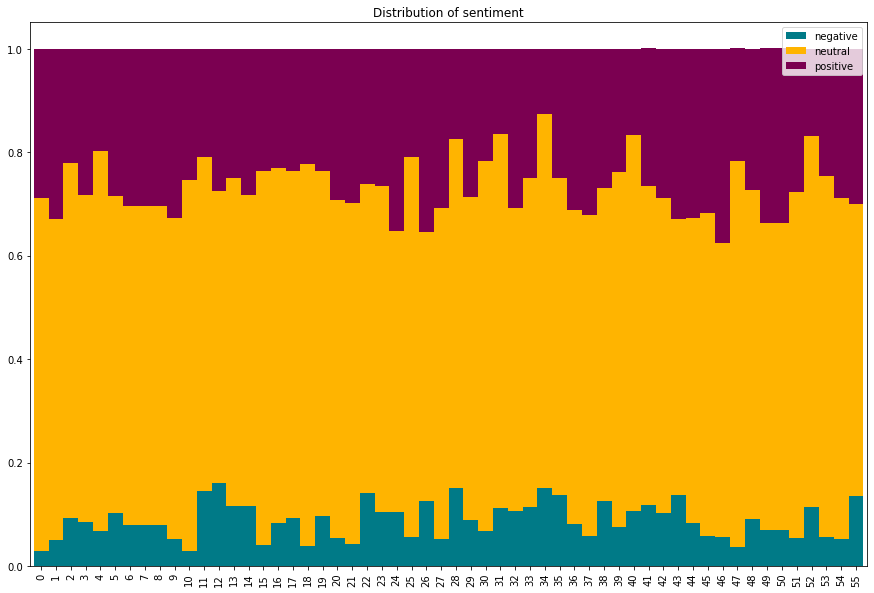

```python
ax = grouped_results[['negative', 'neutral', 'positive']].plot(kind = 'bar',
                                                               stacked = True,
                                                               figsize = (15,10),
                                                               width = 1,
                                                               color = [blueGreen, orange, purple],
                                                               title = 'Distribution of sentiment')
```

Sadly the x axis cannot be removed here, so it looks weird.

Interesting pattern - for each paragraph the variance of sentiment is much bigger. Some are very positive, some very neutral. Some event very negative, but these are rare.

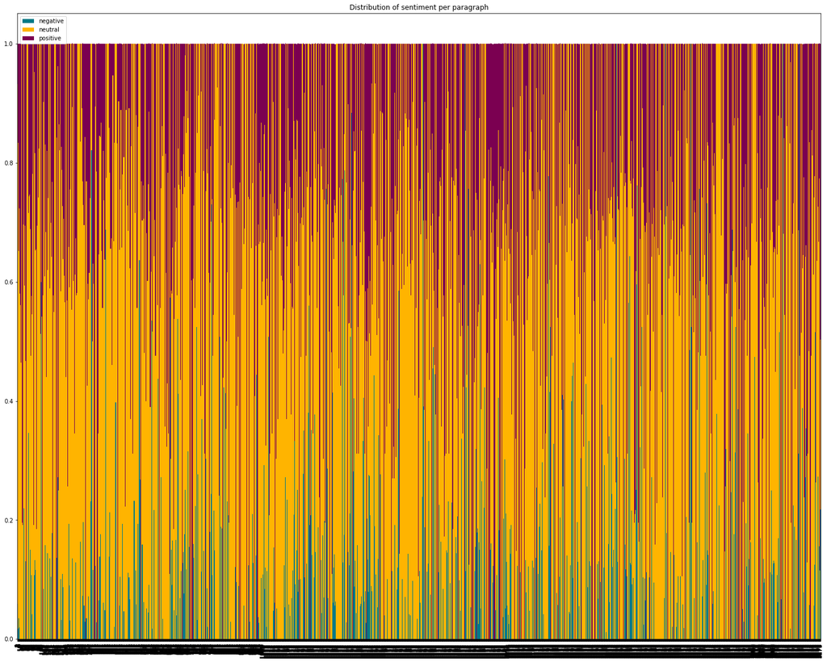

```python
ax = results[['negative', 'neutral', 'positive']].plot(kind = 'bar',
                                                       stacked = True,
                                                       figsize = (25,20),
                                                       width = 1,
                                                       color = [blueGreen, orange, purple],
                                                       title = 'Distribution of sentiment per paragraph')
```

## What about the sentiment ratio?

This measure provides interesting insight. It looks like for some games there is nearly 10 times more positive content than negative!

Note that no games reach negative numbers, and most stay above 2 (that is 2x more positive than negative).

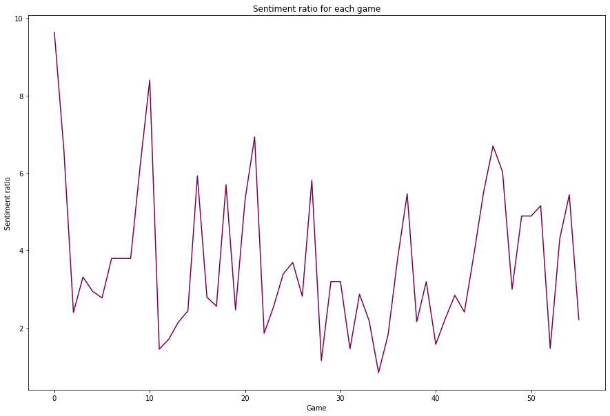

```python
fig, ax = plt.subplots(figsize=(15,10))
ax.plot('sentiment_ratio', data = grouped_results, color = purple)
plt.title('Sentiment ratio for each game')
plt.ylabel('Sentiment ratio')
plt.xlabel('Game')
plt.show()
```

## Let's confirm the spread of sentiment

The values on the plot axis confirm that the reviews are mostly positive. Interestingly, there are no other patterns here.

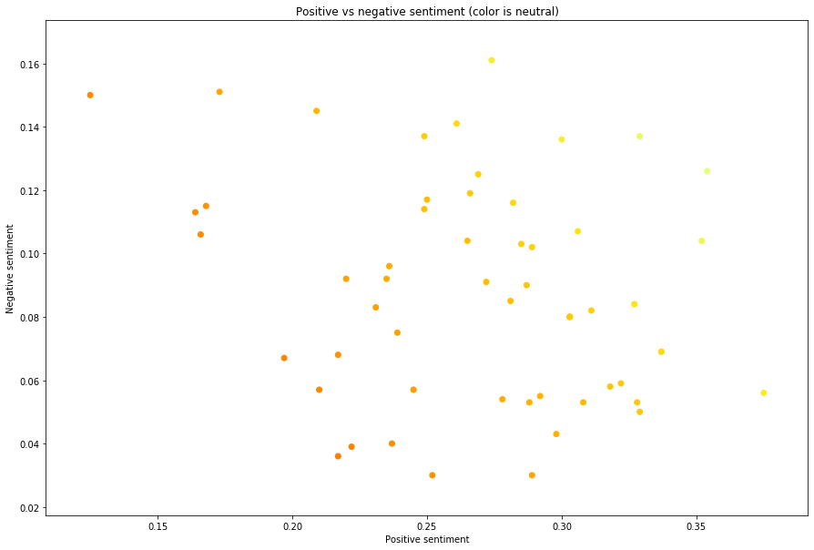

```python
fig, ax = plt.subplots(figsize=(15,10))
ax.scatter('positive', 'negative', c = 'neutral', data = grouped_results, cmap="Wistia")
plt.title('Positive vs negative sentiment (color is neutral)')
plt.ylabel('Negative sentiment')
plt.xlabel('Positive sentiment')
plt.show()
```

When we look at the paragraph data, interesting conclusions can be drawn. Many paragraphs have 0% of either positive or negative sentiment. The minimal amount of sentiment seems to be about 5% for this data.

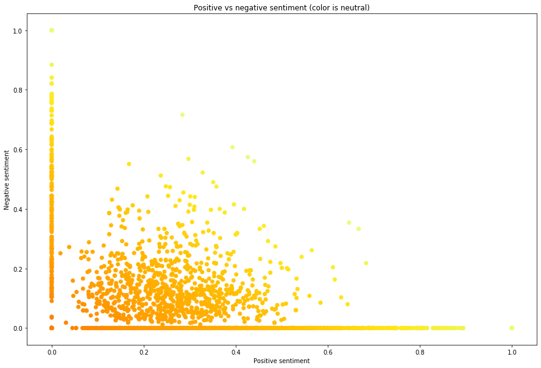

```python
fig, ax = plt.subplots(figsize=(15,10))
ax.scatter('positive', 'negative', c = 'neutral', data = results, cmap="Wistia")
plt.title('Positive vs negative sentiment (color is neutral)')
plt.ylabel('Negative sentiment')
plt.xlabel('Positive sentiment')
plt.show()
```

## Are the ratings correlated with the sentiment?

It seems that there is no correlation between the ratings and the sentiment of the review. The games here represent the typical scale of averages on BGG (6 to 8).

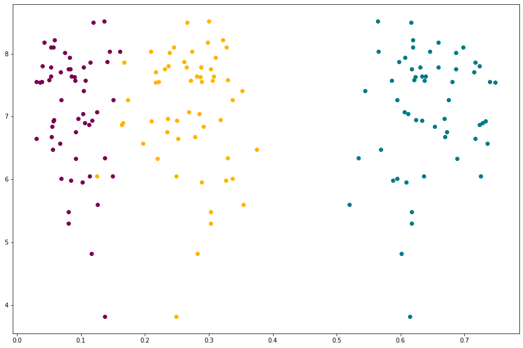

```python
fig, ax = plt.subplots(figsize=(15,10))
ax.scatter('positive', 'average', color = orange, data = grouped_results)
ax.scatter('negative', 'average', color = purple, data = grouped_results)
ax.scatter('neutral', 'average', color = blueGreen, data = grouped_results)
plt.show()
```

The same result is repeated on the paragraph data. No patterns here.

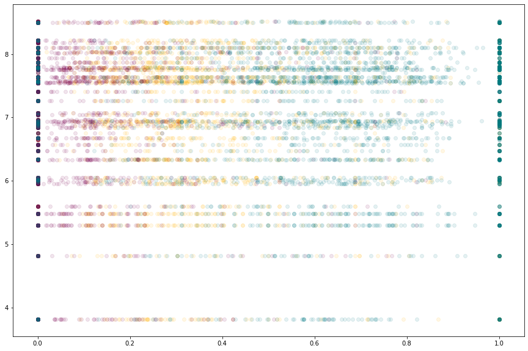

```python
fig, ax = plt.subplots(figsize=(15,10))
ax.scatter('positive', 'average', color = orange, data = results, alpha = 0.1)
ax.scatter('negative', 'average', color = purple, data = results, alpha = 0.1)
ax.scatter('neutral', 'average', color = blueGreen, data = results, alpha = 0.1)
plt.show()
```

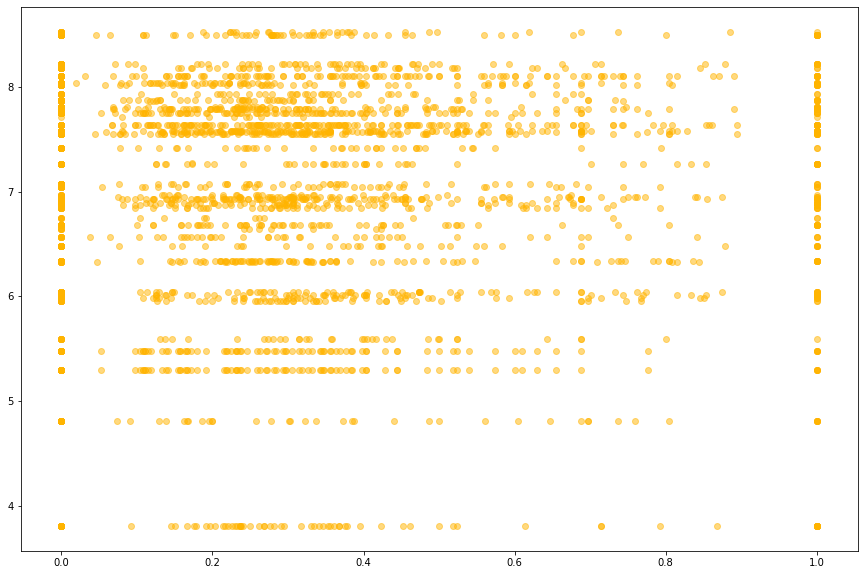

```python
fig, ax = plt.subplots(figsize=(15,10))
ax.scatter('positive', 'average', color = orange, data = results, alpha = 0.5)
plt.show()
```

## What about the sentiment ratio?

Sadly, it seems that there is no correlation here either.

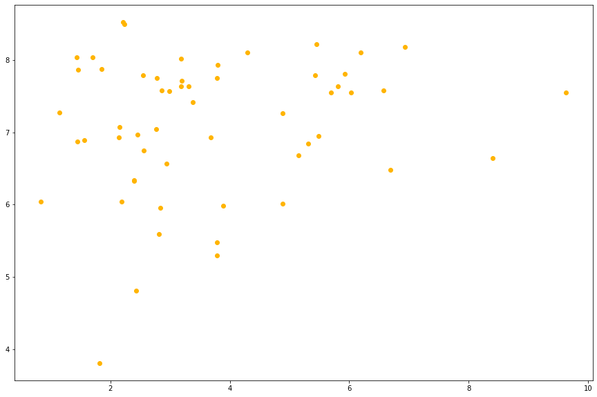

```python
plt.figure(figsize=(15,10))
plt.scatter('sentiment_ratio', 'average', color = orange, data = grouped_results)
plt.show()
```

Same for the paragraph data.

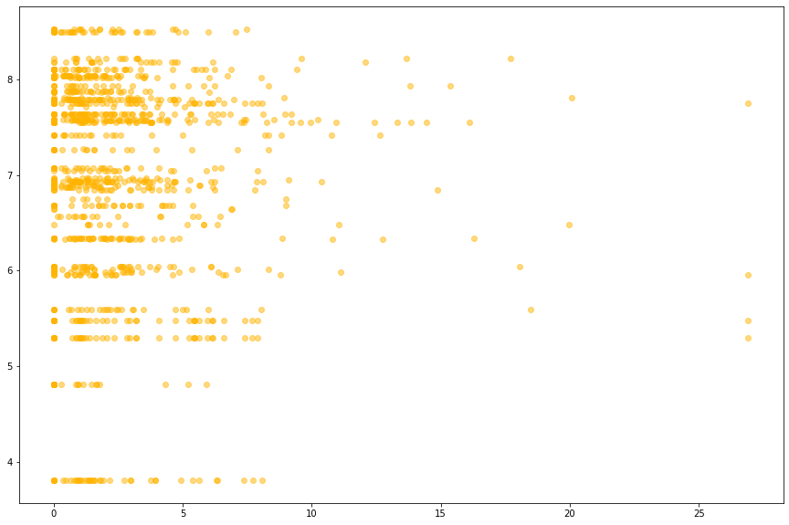

```python
plt.figure(figsize=(15,10))
plt.scatter('sentiment_ratio', 'average', color = orange, data = results, alpha = 0.5)
plt.show()
```